# Client Report - Machine Learning Prediction

- Show All Code
- Hide All Code

Course DS 250

Author

Alex Nielsen

## Elevator pitch

In the following practice exercise I created a decision tree machine learning model to classify a home as built before or after 1980. I used different analyzing and evaluation techniques to better design and test a model that can make accurate predictions.

**Read and format project data**

```python
# Learn morea about Code Cells: https://quarto.org/docs/reference/cells/cells-jupyter.html

# reading data
df = pd.read_csv("https://raw.githubusercontent.com/byuidatascience/data4dwellings/master/data-raw/dwellings_ml/dwellings_ml.csv")
df = df.drop(df[(df.yrbuilt == 2013)].index)
```

## Feature Relationships

**Create 2-3 charts that evaluate potential relationships between the home variables and before1980. Explain what you learn from the charts that could help a machine learning algorithm.**

The following figures show potential relationships between the year a house was built, and its square-footage as well as price. Figure A shows the average liveable area of a home built in a given year. We can see that since the mid-80s, homes tend to be a fair amount larger than before. Figure B represents the average price of a home based on the year it was built. Similarly, The average price, although stable at first, has spiked upward after the 80s. In the mid-2000s it has gone up far beyond any other seemingly due to outliers.

**Read and format data**

```python
# Data formatting

area = {'year': [], 'meanArea': []}
for i in df['yrbuilt']:
  if i not in area['year']:
    area['year'].append(i)
    area['meanArea'].append(df.loc[df['yrbuilt'] == i, 'livearea'].mean())

area_df = pd.DataFrame(area).sort_values('year')
area_df.head(5)

price = {'year': [], 'meanPrice': []}
for i in df['yrbuilt']:
  if i not in price['year']:
    price['year'].append(i)
    price['meanPrice'].append(df.loc[df['yrbuilt'] == i, 'sprice'].mean())

price_df = pd.DataFrame(price).sort_values('year', ascending=False)
```

**liveable area plot**

```python
px.bar(area_df, x='year', y='meanArea', title='Average Square Footage Over Time')
```

[interactive chart not shown]

figure a

**plot example**

```python
px.bar(price_df, x='year', y='meanPrice', title='Average Price Over Time')
```

[interactive chart not shown]

figure b

## Model Building

**Build a classification model labeling houses as being built “before 1980” or “during or after 1980”. Your goal is to reach or exceed 90% accuracy. Explain your final model choice (algorithm, tuning parameters, etc) and describe what other models you tried.**

**Model Construction**

```python
# Building model
ml_df = df.drop(['parcel', 'yrbuilt'], axis=1)

from sklearn.model_selection import train_test_split
from sklearn import metrics
from sklearn import tree

X_train, X_test, y_train, y_test = train_test_split(ml_df.drop('before1980', axis=1), ml_df.before1980, test_size=.2, random_state=42)

clf = tree.DecisionTreeClassifier()
clf.fit(X_train, y_train)

pred = clf.predict(X_test)
```

## Significant Features

**Justify your classification model by discussing the most important features selected by your model. This discussion should include a chart and a description of the features.**

The two pie charts shown below display the distribution of the most important feature determined by the model. A decision tree model splits the dataset by given features by first determining which feature brings the dataset to the most homogenous state with either all of one class on either side of the tree. While this is never truly possible in one feature, usually some features better split the data than others. In this case, the model found that the number of stories was the most influential feature. The first chart shows that almost every 1 story house in the dataset was built before 1980. Conversely, the majority (about 55%) of homes with more than one story was built after 1980.

**Read and format data**

```python
# Feature Charts
story_df = df[['before1980', 'arcstyle_ONE-STORY']]
one_story = story_df[story_df['arcstyle_ONE-STORY'] == 1]
more_stories = story_df[story_df['arcstyle_ONE-STORY'] == 0]

one_pie = px.pie(one_story, names='before1980', title='Houses built before 1980 with one story', color='before1980')
one_pie.show()
```

[interactive chart not shown]

one story

**Read and format data**

```python
# Feature Charts
more_pie = px.pie(more_stories, names='before1980', title='Houses built before 1980 with several stories', color='before1980')
more_pie.show()
```

[interactive chart not shown]

several stories

## Model Evaluation

**Describe the quality of your classification model using 2-3 different evaluation metrics. You also need to explain how to interpret each of the evaluation metrics you use.**

**accuracy metrics**

```
Modle Accuracy: 90.60000000000001%
```

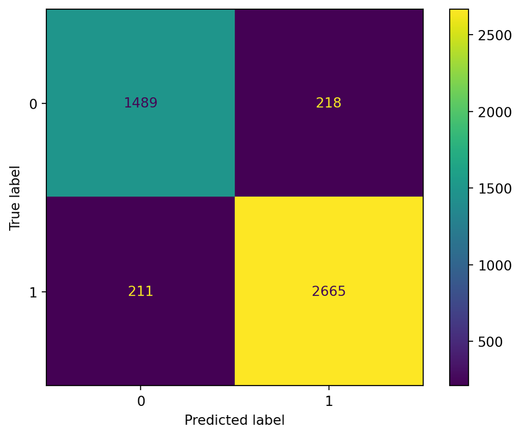

confusion matrix and accuracies

```python
import matplotlib as plt

print(f'Modle Accuracy: {round(metrics.accuracy_score(y_test, pred), 3)*100}%')
cm = metrics.confusion_matrix(y_test, pred)
disp = metrics.ConfusionMatrixDisplay(confusion_matrix=cm)
disp.plot()
```

```python
from sklearn.model_selection import train_test_split
from sklearn import metrics
from sklearn import tree
df = pd.read_csv("https://raw.githubusercontent.com/byuidatascience/data4dwellings/master/data-raw/dwellings_ml/dwellings_ml.csv")
X_train, X_test, y_train, y_test = train_test_split(df.drop('before1980', axis=1), df.before1980, test_size=.34, random_state=76)

X_train['sprice'].head(10)
```

```
18275      620000
17932      714000
5121       244500
12314       98000
790      17113000
9632       432500
11472      485000
19039      724500
3810       185700
16059      702500
Name: sprice, dtype: int64
```

Back to top